# Happy Moments

Tao Han

## Let’s look at what makes people happy.

[interactive chart not shown]

## What are the top 10 key words that appear in people’s mind when thinking about happy moments?

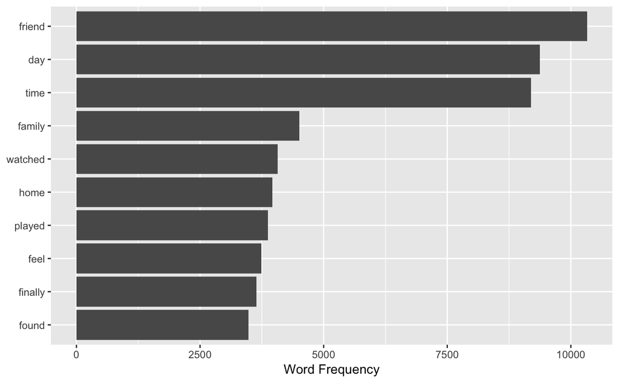

## It looks like people will think about “friend”, “family” and “home”. But what about those other words, which seem to be coming in pairs. let’s look at the top 10 phrases that appear in people’s mind when thinking about happy moments.

| word1 | word2 | n |
| --- | --- | --- |
| spend | time | 774 |
| video | game | 718 |
| moment | life | 585 |
| ice | cream | 505 |
| watched | movie | 482 |
| birthday | party | 448 |
| mother | day | 412 |
| spent | time | 309 |
| played | game | 300 |
| friend | mine | 296 |

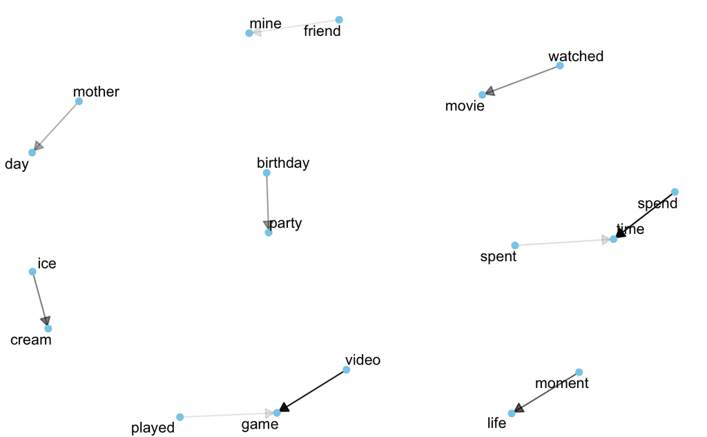

## People will be happy if they play “video game”, eat “ice cream”, have “birthday party” etc.

# Who is playing video games?

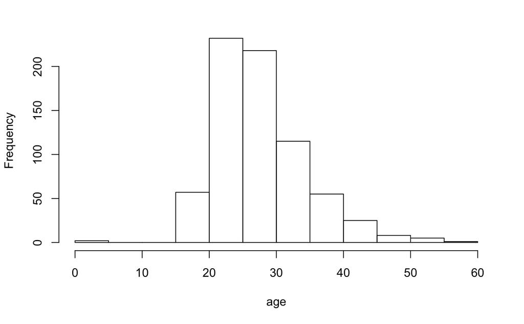

# Who is having ice creams?

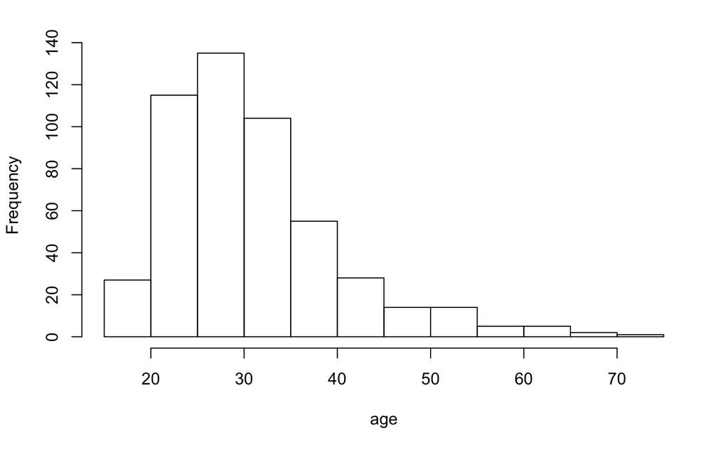

# Who is having birthday party?

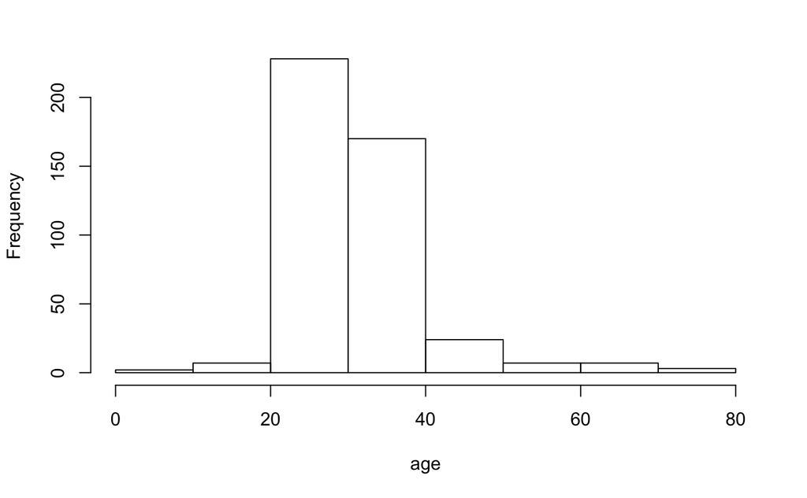

## It looks like it is young people. Do young people really differ form elder people?

# People under 40 years old

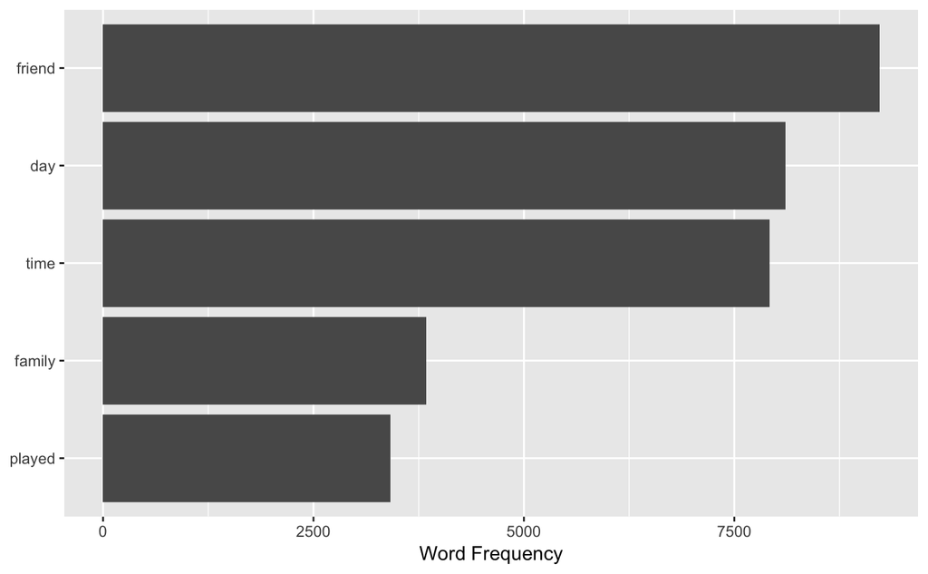

# People over 40 years old

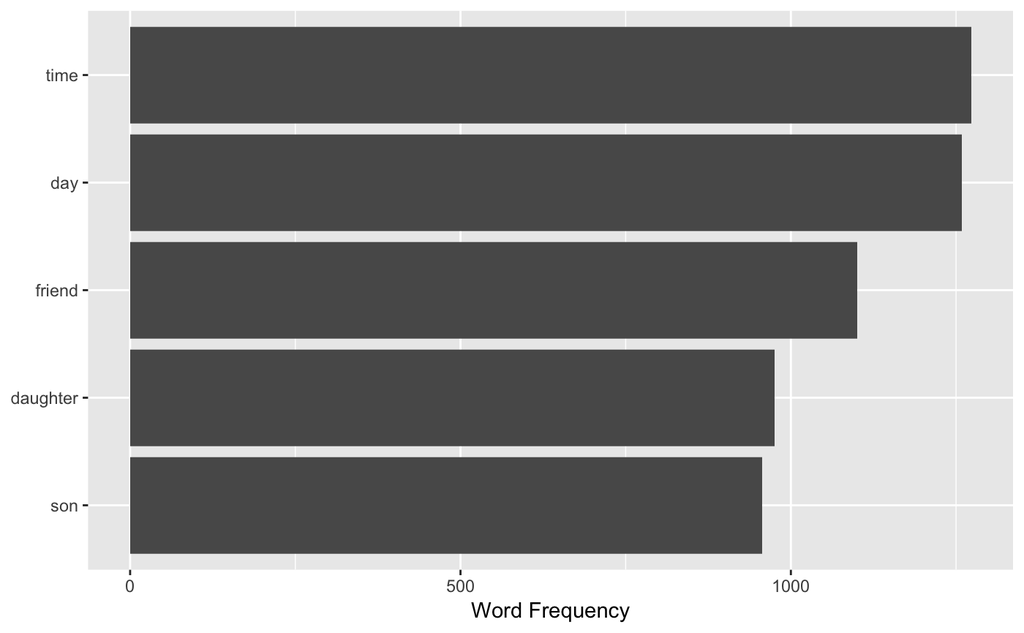

## Spending time with family can bring elder people more happiness, while having time to hang out with friend can make young people more happy.

## What about gender? Male enjoy having their friends while female likes to stay with families.

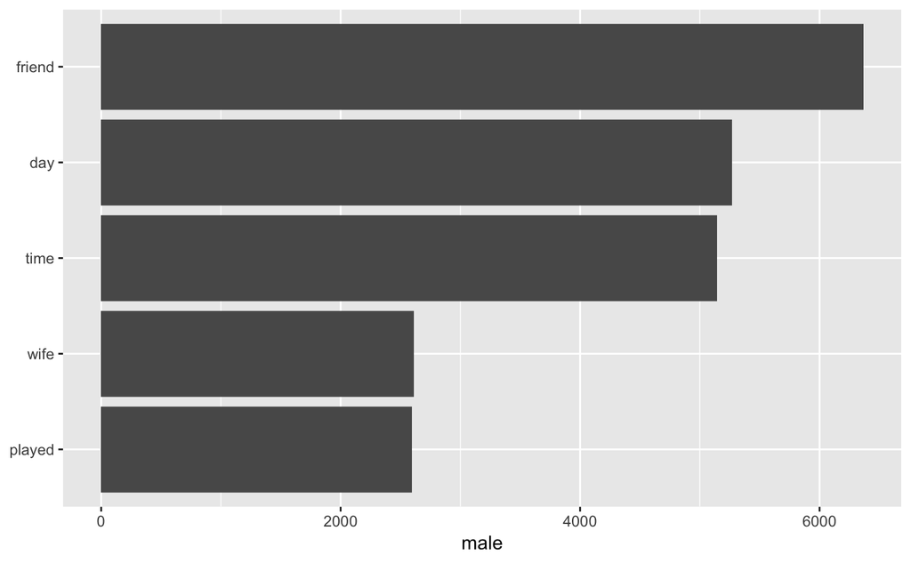

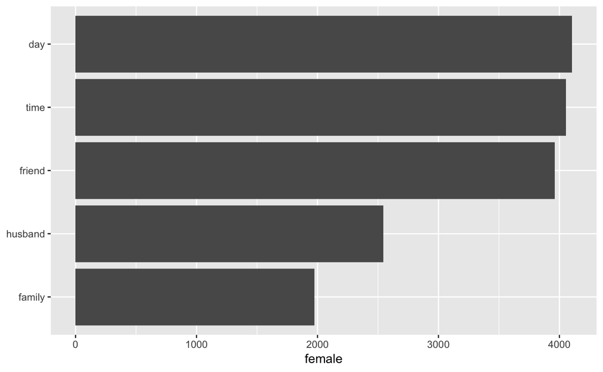

## Which is the more dominating factor, age or gender? As we can tell, age a is more important factor.

# Male group

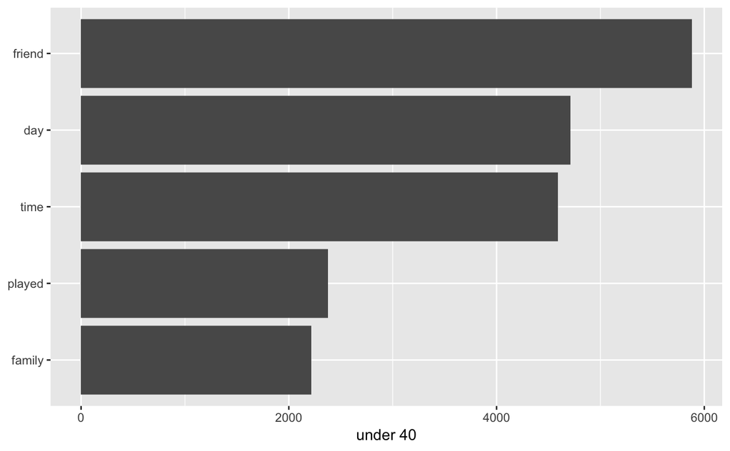

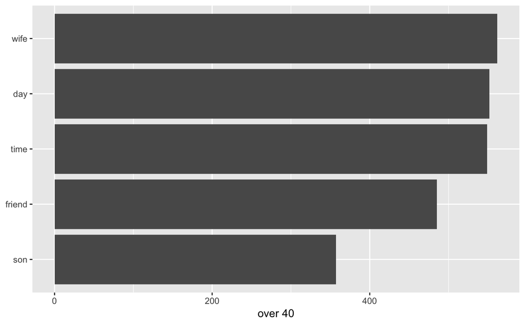

# Female group

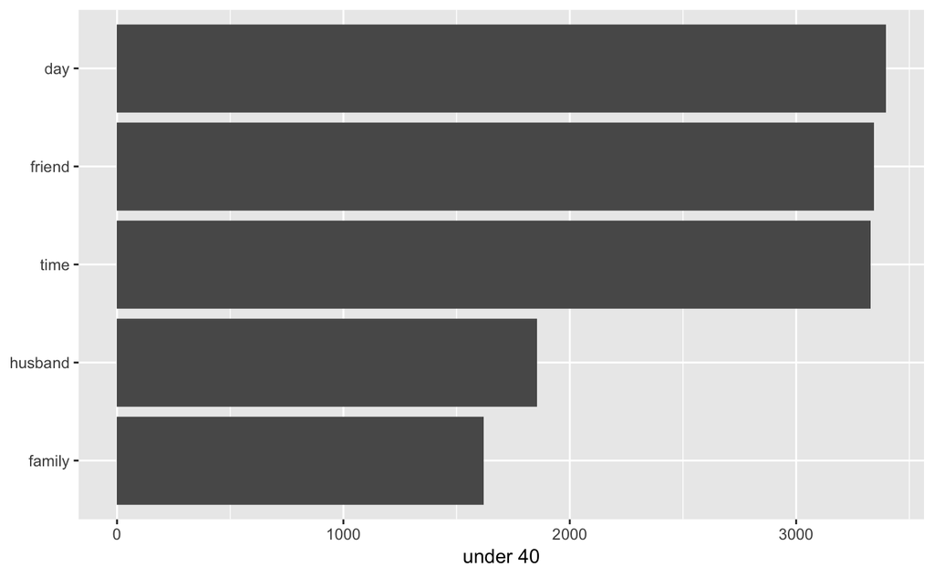

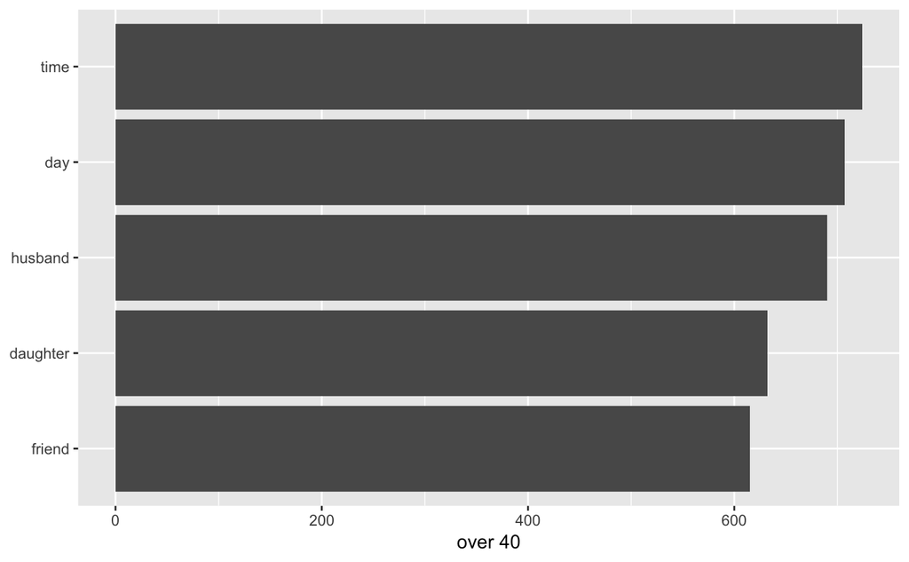

## If age is important, is it because of the marriage? Yes, family can bring more happiness to married people.

# Married group

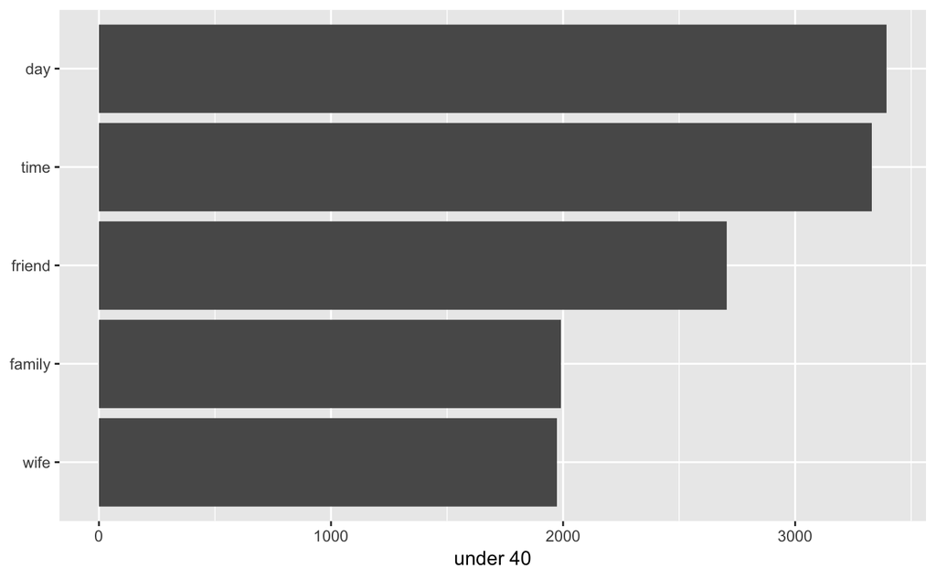

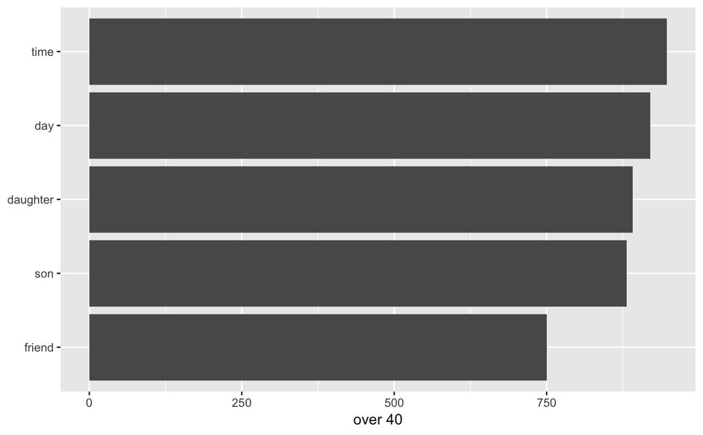

# Single group

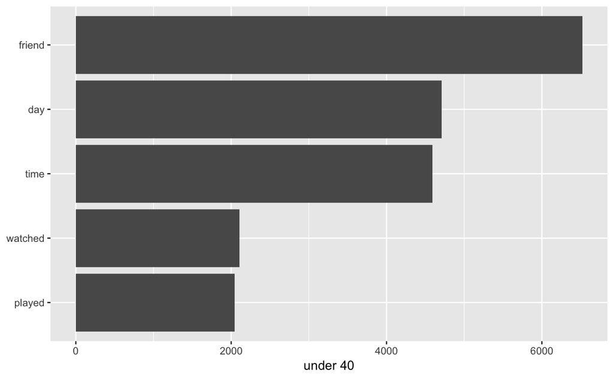

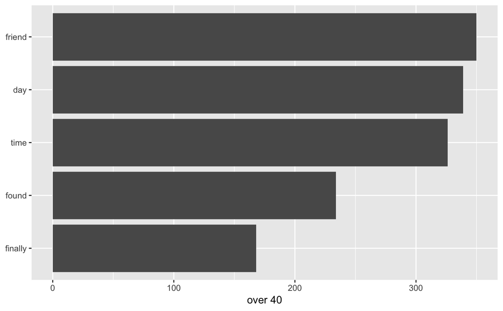